# Part II - The patterns of the usage of the bike-sharing services

## by Jinwoong Nam

## Investigation Overview

In this investigation, I aim to look at the pattern of the usage of the bike-sharing service that can give many insights into developing strategies to help encourage more people to use the services. To do this, duration, start time, user type (subscriber or customer), and whether or not bike sharing is used for the whole trip are explored.

## Dataset Overview

The data consisted of information regarding 183,412 usages of the bike-sharing service in the greater San Francisco Bay area during February 2019. The attributes included duration, start/end time, station, member birth year, member gender, user type, whether or not bike sharing is used for the whole trip, and so on. 8,460 data points were removed from the analysis due to missing information.

## Distribution of the Duration

Duration per trip in the dataset takes on a very large range of values, from about 1 minute to about 23 hours. Plotted on a logarithmic scale, the distribution of durations takes on a normal distribution shape.

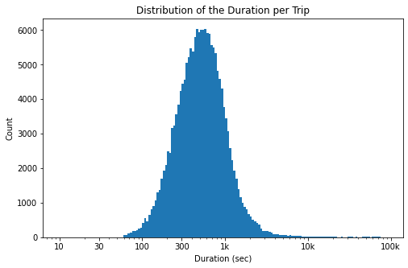

## Distribution of the Usage

Generally, the usage is high on weekdays and low on weekends. During the day, morning (8-10 am) and evening (4-6 pm) have the highest usage.

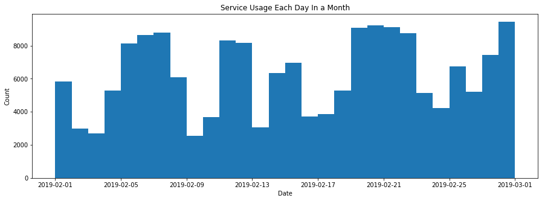

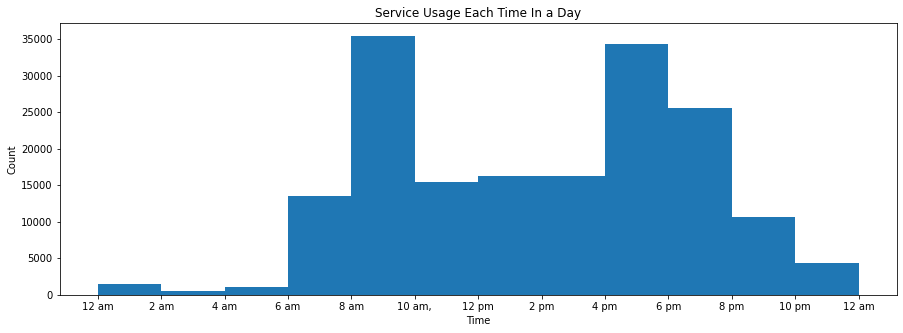

## Distribution of the User Type

There are two user types, subscribers and customers. Subscribers are the users who subscribe to the bike-sharing service while customers are the users who do not subscribe to the service.

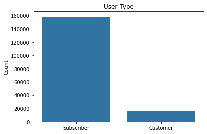

## Start Time by User and Trip Type

Start time are investigated for subscribers and customers. Then, it is studied with the yes and the no group for the question of bike-sharing services for all trips.

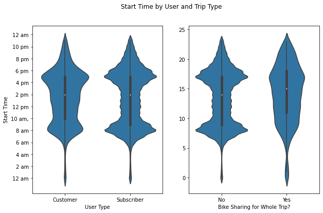